# Graphiques communs avec RMarkdown

Groupe OPEN 2022

18 mai 2022

Ce rapport présente les différentes graphiques produit par le groupe OPEN22 à l’aide des jeux de données provenant du livre R4DS mais aussi des outils du tidverse.

# Graphiques de Clovis BRIGGIO et Léa DANIELI :

Sur la graphique **ci-dessous à gauche**, nous observons une augmentation linéaire du temps de vol en fonction de la distance du trajet.On peut voir également une variabilité de temps au sein de chaque trajet.**CB**

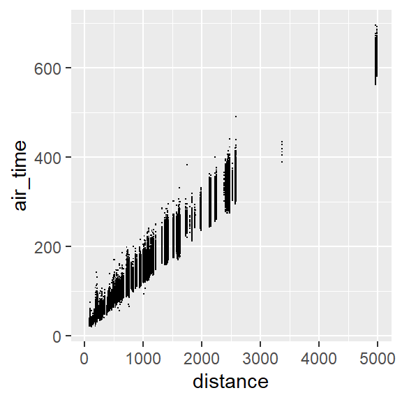

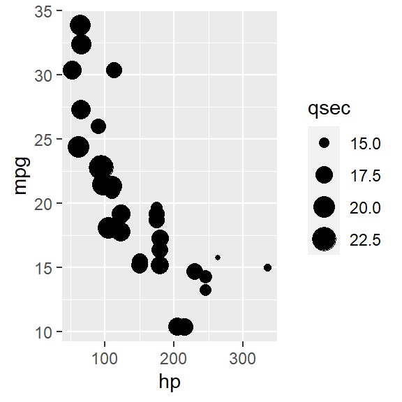

Le jeu de données mtcars compare plusieurs modèles de véhicules. Le graphique **ci-dessus à droite** représentant la consommation (mpg) en fonction de la puissance (cv). Le temps d’accélération (qsec) est également mentionné.**LD**

# Graphiques de Jeanne HECKENBENNER et Ghislaine KOSSONOU :

Le graphique **ci-dessous à gauche** représente un diagramme de densité. Il permet d’observer la distribution d’une variable continue ici, la taille des personnages.**JH**

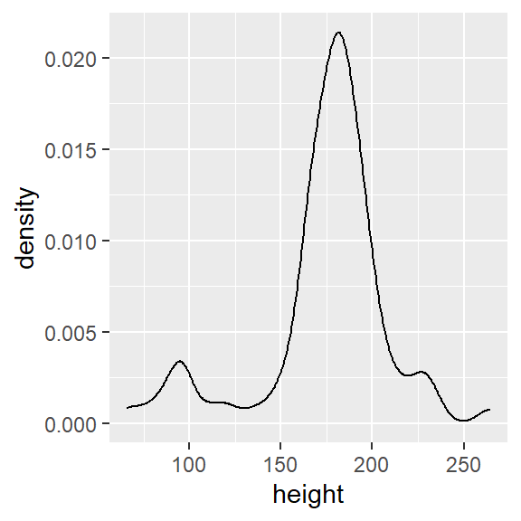

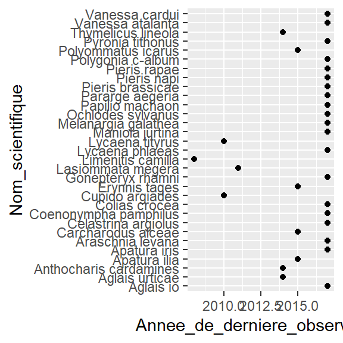

# Graphiques de Manon LAFONT et Christophe LENZI :

Le graphique **ci-dessous à gauche** montre un histogramme présentant la répartition des longueurs des sépales d’iris.**ML**

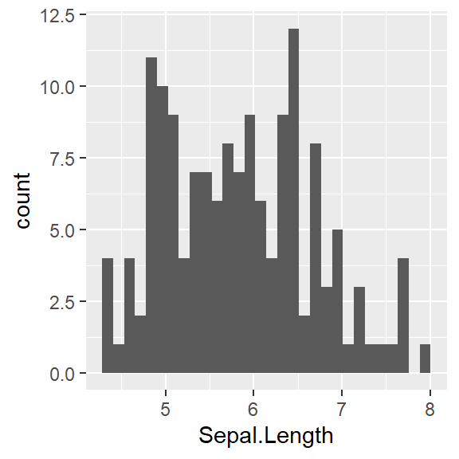

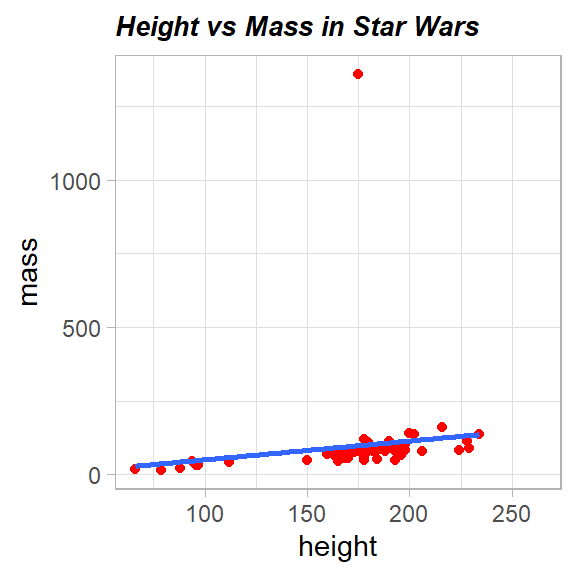

# Graphiques de Pauline M PERRIN et Léa SAGNE :

Le graphique **ci-dessous à gauche** présente le jeu de données nycflights13 regroupant des informations issues de différentes compagnies aériennes qui volent à partir de différents aéroports de New York City. . En utilisant ce jeu de données, nous avons établi un graphique des proportions de vols réalisés par chacune des compagnies aériennes (carrier). Ainsi, en 2013, la compagnie aérienne ayant réalisé le plus grand nombre de vols au départ des différents aéroports de New York est United Airlines (UA). Elle est suivie par JetBlue (B6), EspressJet (Ev) et Delta (DL) **PP**

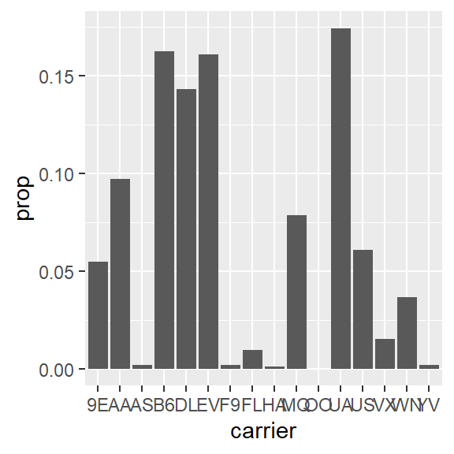

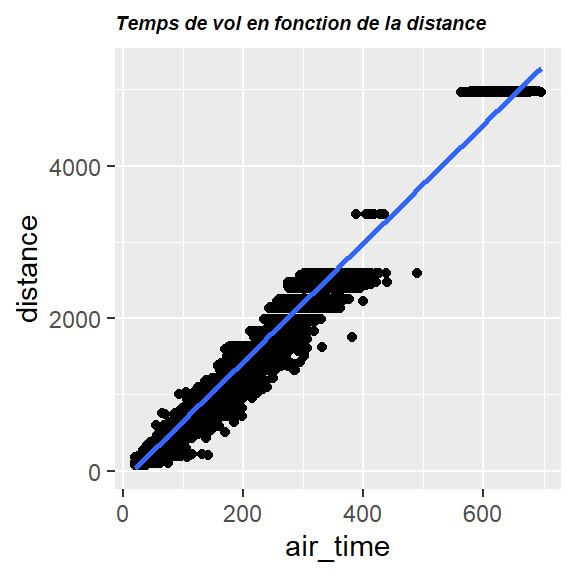

# Graphique d’Hélène VIGNON :

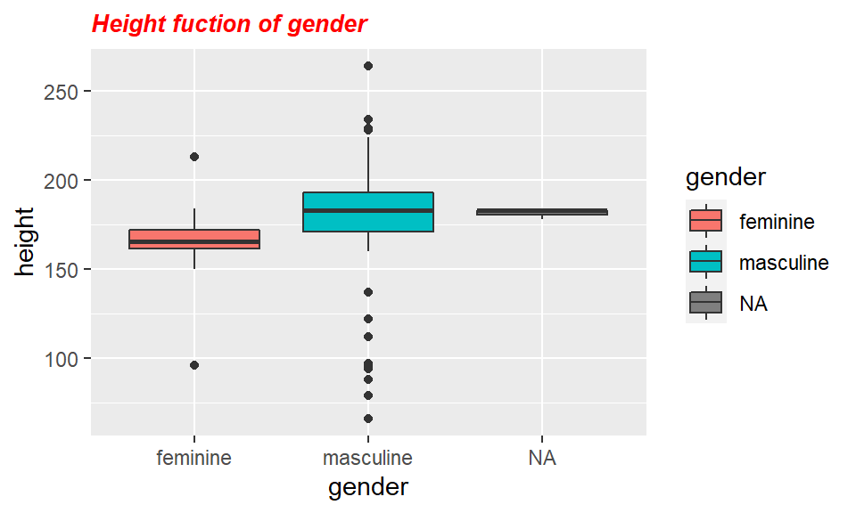